# Introduction to hacksig

Hacksig is a collection of cancer transcriptomics gene signatures as well as a simple and tidy interface to compute single sample enrichment scores.

This document will show you how to getting started with hacksig, but first, we must load the following packages:

```r
library(hacksig)

# to plot and transform data
library(dplyr)
library(ggplot2)
library(purrr)
library(tibble)
library(tidyr)

# to get the MSigDB gene signatures
library(msigdbr)

# to parallelize computations
library(future)

theme_set(theme_bw())
```

## Get implemented signatures

In order to get a complete list of the implemented signatures, you can use `get_sig_info()`. It returns a tibble with very useful information:

- the `signature_id`;
- a string of keywords associated to a signature (separated by the “pipe” `|` symbol);
- the `publication_doi` linking to the original publication;
- a brief `description`.

```r
get_sig_info()
```

```
#> # A tibble: 23 × 4
#>   signature_id       signature_keywords     publication_doi   description
#>   <chr>              <chr>                  <chr>             <chr>
#> 1 ayers2017_immexp   ayers2017_immexp|immu… 10.1172/JCI91190  Immune expanded g…
#> 2 bai2019_immune     bai2019_immune|head a… 10.1155/2019/386… Immune/inflammato…
#> 3 cinsarc            cinsarc|metastasis|sa… 10.1038/nm.2174   Biomarker aimed a…
#> 4 dececco2014_int172 dececco2014_int172|he… 10.1093/annonc/m… Signature aimed a…
#> 5 eschrich2009_rsi   eschrich2009_rsi|radi… 10.1016/j.ijrobp… Genes aimed at pr…
#> # … with 18 more rows
```

To get a full view of the tibble, use:

```r
get_sig_info() %>% print(n = Inf)
# or
View(get_sig_info())
```

If you want to get the list of gene symbols for one or more of the implemented signatures, then use `get_sig_genes()` with valid keywords:

```r
get_sig_genes("ifng")
```

```
#> $muro2016_ifng
#> [1] "CXCL10"  "CXCL9"   "HLA-DRA" "IDO1"    "IFNG"    "STAT1"
```

## Check your signatures

The first thing you should do before computing scores for a signature is to check how many of its genes are present in your data. To accomplish this, we can use `check_sig()` on a normalized gene expression matrix (either microarray or RNA-seq normalized data), which must be formatted as an object of class `matrix` or `data.frame` with gene symbols as row names and sample IDs as column names.

For this tutorial, we will use `test_expr` (an R object included in hacksig) as an example gene expression matrix with 20 simulated samples.

By default, `check_sig()` will compute statistics for every signature implemented in `hacksig`.

```r
check_sig(test_expr)
```

```
#> # A tibble: 23 × 5
#>   signature_id     n_genes n_present frac_present missing_genes
#>   <chr>              <int>     <int>        <dbl> <named list>
#> 1 muro2016_ifng          6         4        0.667 <chr [2]>
#> 2 wu2020_metabolic      30        20        0.667 <chr [10]>
#> 3 liu2020_immune         6         4        0.667 <chr [2]>
#> 4 liu2021_mgs            6         4        0.667 <chr [2]>
#> 5 estimate_stromal     141        91        0.645 <chr [50]>
#> # … with 18 more rows
```

You can filter for specific signatures by entering keywords in the `signatures` argument (partial match and regular expressions will work):

```r
check_sig(test_expr, signatures = c("metab", "cinsarc"))
```

```
#> # A tibble: 2 × 5
#>   signature_id     n_genes n_present frac_present missing_genes
#>   <chr>              <int>     <int>        <dbl> <named list>
#> 1 wu2020_metabolic      30        20        0.667 <chr [10]>
#> 2 cinsarc               67        40        0.597 <chr [27]>
```

We can also check for signatures not implemented in hacksig, that is custom signatures. For example, we can use the `msigdbr` package to download the *Hallmark* gene set collection as a tibble and transform it into a list:

```r
hallmark_list <- msigdbr(species = "Homo sapiens", category = "H") %>%
    distinct(gs_name, gene_symbol) %>%
    nest(genes = c(gene_symbol)) %>%
    mutate(genes = map(genes, compose(as_vector, unname))) %>%
    deframe()

check_sig(test_expr, hallmark_list)
```

```
#> # A tibble: 50 × 5
#>   signature_id                      n_genes n_present frac_present missing_genes
#>   <chr>                               <int>     <int>        <dbl> <named list>
#> 1 HALLMARK_WNT_BETA_CATENIN_SIGNAL…      42        27        0.643 <chr [15]>
#> 2 HALLMARK_APICAL_SURFACE                44        28        0.636 <chr [16]>
#> 3 HALLMARK_BILE_ACID_METABOLISM         112        70        0.625 <chr [42]>
#> 4 HALLMARK_NOTCH_SIGNALING               32        20        0.625 <chr [12]>
#> 5 HALLMARK_PI3K_AKT_MTOR_SIGNALING      105        65        0.619 <chr [40]>
#> # … with 45 more rows
```

Missing genes for the `HALLMARK_NOTCH_SIGNALING` gene set are:

```r
check_sig(test_expr, hallmark_list) %>%
    filter(signature_id == "HALLMARK_NOTCH_SIGNALING") %>%
    pull(missing_genes)
```

```
#> $HALLMARK_NOTCH_SIGNALING
#>  [1] "FZD5"    "HEYL"    "KAT2A"   "MAML2"   "NOTCH1"  "NOTCH3"  "PPARD"
#>  [8] "PRKCA"   "PSEN2"   "SAP30"   "ST3GAL6" "TCF7L2"
```

## Compute single sample scores

### hack_sig

The main function of the package, `hack_sig()`, permits to obtain single sample scores from gene signatures. By default, it will compute scores for all the signatures implemented in the package with the original publication method.

```r
hack_sig(test_expr)
```

You can also filter for specific signatures (e.g. the immune and stromal ESTIMATE signatures) and choose a particular single sample method:

```r
hack_sig(test_expr, signatures = "estimate", method = "zscore")
```

```
#> # A tibble: 20 × 3
#>   sample_id estimate_immune estimate_stromal
#>   <chr>               <dbl>            <dbl>
#> 1 sample1            -2.65            -0.262
#> 2 sample2             1.19            -0.717
#> 3 sample3            -0.455            0.254
#> 4 sample4            -0.722            2.19
#> 5 sample5            -1.07             0.112
#> # … with 15 more rows
```

Valid choices for single sample `method`s are:

- `"zscore"`, for the combined z-score;
- `"ssgsea"`, for the single sample GSEA;
- `"singscore"`, for the singscore method.

Run `?hack_sig` to see additional parameter specifications for these methods.

As in `check_sig()`, the argument `signatures` can also be a list of gene signatures. For example, we can compute normalized single sample GSEA scores for the Hallmark gene sets:

```r
hack_sig(test_expr, hallmark_list,
         method = "ssgsea", sample_norm = "separate", alpha = 0.5)
```

```
#> # A tibble: 20 × 51
#>   sample_id HALLMARK_ADIPOGE… HALLMARK_ALLOGR… HALLMARK_ANDROG… HALLMARK_ANGIOG…
#>   <chr>                 <dbl>            <dbl>            <dbl>            <dbl>
#> 1 sample1               0.683            0.419            0.943           0.447
#> 2 sample2               0.501            0.554            0.643           0.612
#> 3 sample3               0.387            0.368            0.695           0.409
#> 4 sample4               0.710            0.524            0.793           0.502
#> 5 sample5               0.339            0.422            0.917           0.0500
#> # … with 15 more rows, and 46 more variables: HALLMARK_APICAL_JUNCTION <dbl>,
#> #   HALLMARK_APICAL_SURFACE <dbl>, HALLMARK_APOPTOSIS <dbl>,
#> #   HALLMARK_BILE_ACID_METABOLISM <dbl>,
#> #   HALLMARK_CHOLESTEROL_HOMEOSTASIS <dbl>, HALLMARK_COAGULATION <dbl>,
#> #   HALLMARK_COMPLEMENT <dbl>, HALLMARK_DNA_REPAIR <dbl>,
#> #   HALLMARK_E2F_TARGETS <dbl>,
#> #   HALLMARK_EPITHELIAL_MESENCHYMAL_TRANSITION <dbl>, …
```

There are three methods for which `hack_sig()` cannot be used to compute gene signature scores with the original method. These are: CINSARC, ESTIMATE and the Immunophenoscore.

### hack_cinsarc

For the CINSARC classification, you must provide a vector with distant metastasis status:

```r
set.seed(123)
rand_dm <- sample(c(0, 1), size = ncol(test_expr), replace = TRUE)
hack_cinsarc(test_expr, rand_dm)
```

```
#> # A tibble: 20 × 2
#>   sample_id cinsarc_class
#>   <chr>     <chr>
#> 1 sample1   C2
#> 2 sample2   C1
#> 3 sample3   C2
#> 4 sample4   C1
#> 5 sample5   C2
#> # … with 15 more rows
```

### hack_estimate

Immune, stromal, ESTIMATE and tumor purity scores from the ESTIMATE method can be obtained with:

```r
hack_estimate(test_expr)
```

```
#> # A tibble: 20 × 5
#>   sample_id immune_score stroma_score estimate_score purity_score
#>   <chr>            <dbl>        <dbl>          <dbl>        <dbl>
#> 1 sample1          -636.         778.           142.        0.811
#> 2 sample2          2118.         703.          2821.        0.524
#> 3 sample3           725.         805.          1530.        0.675
#> 4 sample4           737.        2031.          2768.        0.531
#> 5 sample5           181.        1129.          1310.        0.699
#> # … with 15 more rows
```

### hack_immunophenoscore

Finally, the raw immunophenoscore and its discrete (0-10 normalized) counterpart can be obtained with:

```r
hack_immunophenoscore(test_expr)
```

```
#> # A tibble: 20 × 3
#>   sample_id raw_score ips_score
#>   <chr>         <dbl>     <dbl>
#> 1 sample1      0.942          3
#> 2 sample2     -0.348          0
#> 3 sample3      0.0939         0
#> 4 sample4     -0.335          0
#> 5 sample5      1.64           5
#> # … with 15 more rows
```

You can also obtain all biomarker scores with:

```r
hack_immunophenoscore(test_expr, extract = "all")
```

```
#> # A tibble: 20 × 19
#>   sample_id raw_score ips_score ec_score mhc_score sc_score cp_score
#>   <chr>         <dbl>     <dbl>    <dbl>     <dbl>    <dbl>    <dbl>
#> 1 sample1      0.942          3  -0.148      0.312   0.652    0.126
#> 2 sample2     -0.348          0   0.0679    -0.796  -0.0268   0.407
#> 3 sample3      0.0939         0   0.0347    -0.483  -0.0843   0.627
#> 4 sample4     -0.335          0   0.292     -0.777   0.166   -0.0161
#> 5 sample5      1.64           5   0.0607     0.876  -0.0742   0.778
#> # … with 15 more rows, and 12 more variables: act_cd8_score <dbl>,
#> #   tem_cd8_score <dbl>, tem_cd4_score <dbl>, b2m_score <dbl>,
#> #   act_cd4_score <dbl>, treg_score <dbl>, mdsc_score <dbl>, cd27_score <dbl>,
#> #   icos_score <dbl>, pd1_score <dbl>, pdl2_score <dbl>, tigit_score <dbl>
```

## Stratify your samples

If you want to categorize your samples into two or more signature classes based on a score cutoff, you can use `hack_class()` after `hack_sig()`:

```r
test_expr %>%
    hack_sig("estimate", method = "singscore", direction = "up") %>%
    hack_class()
```

```
#> # A tibble: 20 × 3
#>   sample_id estimate_immune estimate_stromal
#>   <chr>     <chr>           <chr>
#> 1 sample1   low             low
#> 2 sample2   high            low
#> 3 sample3   low             low
#> 4 sample4   low             high
#> 5 sample5   low             high
#> # … with 15 more rows
```

By default, `hack_class()` will stratify samples either with the original publication method (if any) or by the median score (otherwise). `hack_class()` will work only with signatures implemented in `hacksig`.

## Speed-up computation time

Our rank-based single sample method implementations (i.e. single sample GSEA and singscore) are slower than their counterparts implemented in `GSVA` and `singscore`. Hence, to speed-up computation time you can use the `future` package:

```r
plan(multisession)
hack_sig(test_expr, hallmark_list, method = "ssgsea")
```

```
#> # A tibble: 20 × 51
#>   sample_id HALLMARK_ADIPOGE… HALLMARK_ALLOGR… HALLMARK_ANDROG… HALLMARK_ANGIOG…
#>   <chr>                 <dbl>            <dbl>            <dbl>            <dbl>
#> 1 sample1               1593.             709.            2013.            1396.
#> 2 sample2               1279.            1052.            1067.            1672.
#> 3 sample3               1061.             661.            1151.            1145.
#> 4 sample4               1613.             954.            1677.            1586.
#> 5 sample5                818.             804.            1866.             622.
#> # … with 15 more rows, and 46 more variables: HALLMARK_APICAL_JUNCTION <dbl>,
#> #   HALLMARK_APICAL_SURFACE <dbl>, HALLMARK_APOPTOSIS <dbl>,
#> #   HALLMARK_BILE_ACID_METABOLISM <dbl>,
#> #   HALLMARK_CHOLESTEROL_HOMEOSTASIS <dbl>, HALLMARK_COAGULATION <dbl>,
#> #   HALLMARK_COMPLEMENT <dbl>, HALLMARK_DNA_REPAIR <dbl>,
#> #   HALLMARK_E2F_TARGETS <dbl>,
#> #   HALLMARK_EPITHELIAL_MESENCHYMAL_TRANSITION <dbl>, …
```

## Use case

Let’s say we want to compute single sample scores for the KEGG gene set collection and then correlate these scores with the tumor purity given by the ESTIMATE method.

First, we get the KEGG list and use `check_sig()` to keep only those gene sets whose genes are more than 2/3 present in our gene expression matrix.

```r
kegg_list <- msigdbr(species = "Homo sapiens", subcategory = "KEGG") %>%
    distinct(gs_name, gene_symbol) %>%
    nest(genes = c(gene_symbol)) %>%
    mutate(genes = map(genes, compose(as_vector, unname))) %>%
    deframe()

kegg_ok <- check_sig(test_expr, kegg_list) %>%
    filter(frac_present > 0.66) %>%
    pull(signature_id)
```

Then, we apply both the combined z-score and the ssGSEA method for the resulting list of 10 KEGG gene sets using `purrr::map_dfr()`:

```r
kegg_scores <- map_dfr(list(zscore = "zscore", ssgsea = "ssgsea"),
                       ~ hack_sig(test_expr,
                                  kegg_list[kegg_ok],
                                  method = .x,
                                  sample_norm = "separate"),
                       .id = "method")
```

We can transform the `kegg_scores` tibble in long format using `tidyr::pivot_longer()`:

```r
kegg_scores <- kegg_scores %>%
    pivot_longer(starts_with("KEGG"),
                 names_to = "kegg_id", values_to = "kegg_score")
```

Finally, after computing the tumor purity scores, we can merge the two data sets and plot the results:

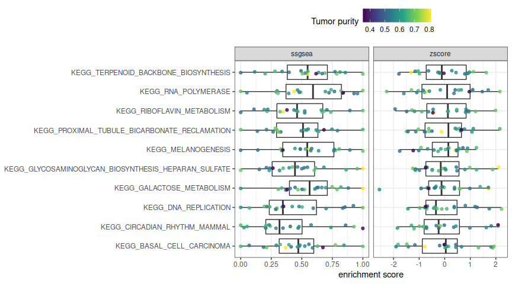

```r
purity_scores <- hack_estimate(test_expr) %>% select(sample_id, purity_score)

kegg_scores %>%
    left_join(purity_scores, by = "sample_id") %>%
    ggplot(aes(x = kegg_id, y = kegg_score)) +
    geom_boxplot(outlier.alpha = 0) +
    geom_jitter(aes(color = purity_score), alpha = 0.8, width = 0.1) +
    facet_wrap(facets = vars(method), scales = "free_x") +
    coord_flip() +
    scale_color_viridis_c() +
    labs(x = NULL, y = "enrichment score", color = "Tumor purity") +
    theme(legend.position = "top")
```